# Malaria Data Modeling workshop

Introduction to uv, VSCode, Streamlit and Aider

## 📱 Follow Along on Your Device

Scan this code to view the slides on your phone or laptop:

[figure not shown]

## What We’ll Cover Today

1. **Installing Tools** - uv and Aider setup
2. **Project Initialization** - Creating your workspace
3. **Configuration** - OpenRouter API and Aider settings
4. **Installing Dependencies** - Adding required libraries
5. **The Development Workflow** - Building with AI
6. **Running the Application** - Launching your dashboard

# Part 1: Installation & Setup

## Install uv

**uv** is an extremely fast Python package and project manager, written in Rust 🦀

### Windows (using winget)

```bash
winget install --id astral-sh.uv
```

### macOS & Linux (Ubuntu)

```bash
curl -LsSf https://astral.sh/uv/install.sh | sh
```

**Check if installed correctly**

```bash
uv --version
```

## Install uv

**uv** is an extremely fast Python package and project manager, written in Rust 🦀

### From Github releases

```markdown
https://github.com/astral-sh/uv/releases
```

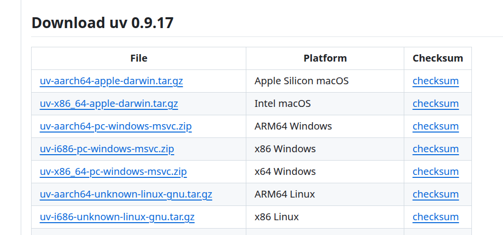

## Why is uv So Fast?

### Key Features

- **10-100x faster** than pip
- **Unified tool** - replaces pip, poetry, pyenv
- **Reliable** - global caching & lockfiles
- **Cross-platform** - Mac, Windows, Linux

### Built with Rust 🦀

- Compiled to machine code
- Parallel processing
- No GC pauses
- Minimal memory

## Install Aider Globally

### Using uv

```bash
uv tool install aider-chat --python 3.12 --force
```

# Part 2: Project Initialization

## Download from Github repo

[figure not shown]

## Download from Github repo

[figure not shown]

**Unzip the file and cd into it**

```bash
# move into the directory
cd MalariaDataModelingWorkshop-main
```

# Part 3: Configuration

## OpenRouter

**Why we are choosing it:**

- **Unified Access:** Connect to Deepseek, OpenAI, Google, etc via one key.
- **Privacy First:** Settings for “Zero Data Retention.”
- **Future Proof:** New models are available almost immediately.
- **Best Prices:** easy access to low-cost open-source models.

[figure not shown]

*A “Universal Adapter” for AI*

## OpenRouter

**Get the API KEY**

[figure not shown]

```markdown
https://openrouter.ai/
```

## OpenRouter

**Get the API KEY**

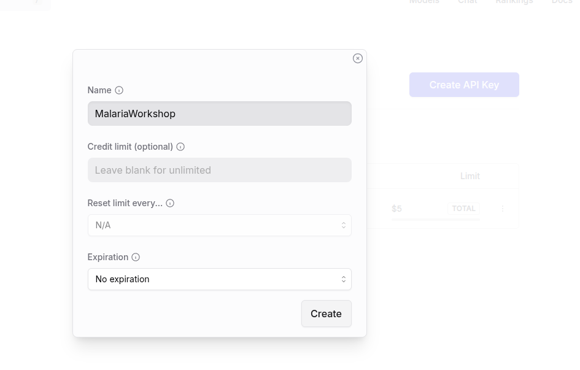

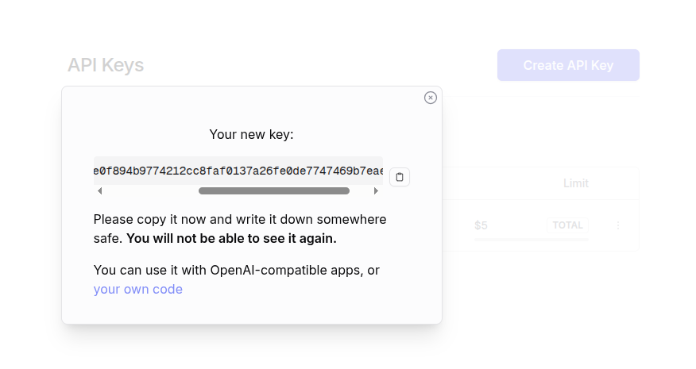

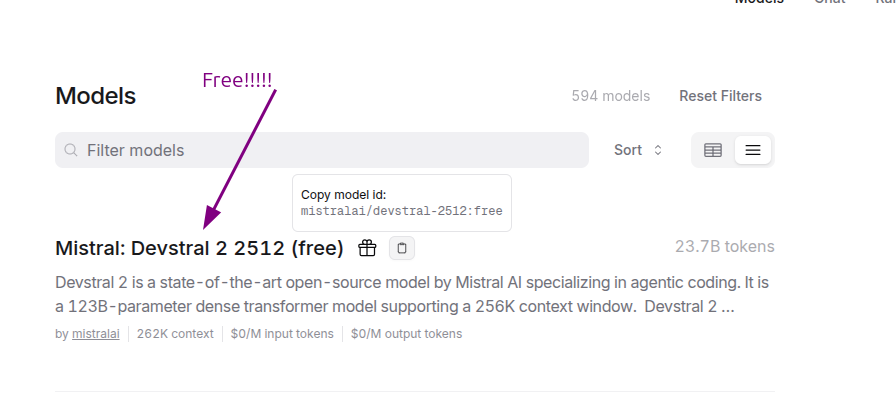

## Create Aider Config File

check the directory for the file below and edit:

**`example.aider.conf.yml`**

```yaml
# ~/.aider.conf.yml

# 1. Add your openRouter API key
# Get one from https://openrouter.ai/settings/keys
api-key: # insert YOUR_OPENROUTER_API_KEY below
 - openrouter=sk-...


# 2. Set your default model (Deepseek, Gemini etc)
model: openrouter/mistralai/devstral-2512:free

# 3. Optional: Enable caching to save on costs
cache-prompts: true
```

**change the name to `.aider.conf.yml` and save**

## Security: Update .gitignore

### Always protect your API keys

```bash
# Add to .gitignore
.aider.conf.yml
.env
*.env
```

# Part 4: Installing Dependencies

## Install Required Libraries

### Add all dependencies upfront

```bash
uv sync
```

## Why Install Dependencies First?

- Aider will use them during test generation
- **TDD** (**T**est-**D**riven **D**evelopment) requires dependencies to be available
- Ensures tests can run immediately
- Prevents import errors during development

# Part 5: The Development Workflow

## Launch Aider

### Basic Command

```bash
aider --no-auto-commits
```

**You’ll see:**

[output not shown]

## If the last launch fails…

**…try the following**

```bash
uv run --with aider-chat python -m aider --model openrouter/<Model-Name> --api-key openrouter=YOUR_OPENROUTER_API_KEY
```

Replace `<Model-Name>` with your desired model (e.g., `Deepseek/deepseek-v3.2` or `mistralai/devstral-2512:free`) and `YOUR_OPENROUTER_API_KEY` with your actual OpenRouter API key.

## The Four-Step Process

1. **Context & Requirements** - Set up the “Expert” persona
2. **Freeze the Spec** - Lock requirements to prevent scope creep
3. **Planning & TDD** - Break work into testable tasks
4. **The Loop** - Iterate through tasks automatically

## Step A: Context & Requirements

### The “Expert” Persona Approach

**Copy the prompt from the PROMPT.md file and paste**

## Step B: Freezing the Spec

### Lock Requirements

Once the PRD is generated, prevent AI from changing it:

```bash
/read-only context/PRD.md
```

**Why?**

- Prevents scope creep
- Maintains focus
- Ensures consistency

## Step C: Planning & TDD

### Create Task List

**This was already accomplished from the instructions on the PROMPT.md. You can check the folder visually to confirm.**

## What Aider Creates

### Example Task List

```markdown
## Tasks

- [ ] 1. Set up project structure
- [ ] 2. Create file upload component
- [ ] 3. Implement CSV validation
- [ ] 4. Add EDA functions
- [ ] 5. Create visualization module
- [ ] 6. Build main dashboard layout
- [ ] 7. Write tests for each component
```

## Step D: The Loop

### The Simple Iteration Command

```
Please proceed to the next task.
```

**That’s it!**

## Essential Aider Commands

- `/add file.py` - Add file to context
- `/read-only file.py` - Prevent modifications
- `/drop file.py` - Remove from context
- `/ls` - List files in context
- `/undo` - Undo last change
- `/diff` - Show pending changes
- `/help` - Show all commands
- `/exit` - Exit aider

# Part 6: Running the Application

## Launch the App

### Using uv run

```bash
uv run streamlit run app.py
```

**No activation needed!**

`uv run` automatically uses the virtual environment

## Key Principles

**Isolated environments**

- Use `uv` for reproducible dependencies
- Fast, reliable, consistent

## Resources

### Documentation

- **uv**: docs.astral.sh/uv
- **OpenRouter**: https://openrouter.ai/
- **Aider**: aider.chat/docs
- **Streamlit**: docs.streamlit.io

## What’s Next?

1. Set up your own dashboard project
2. Try the expert persona approach
3. Experiment with task decomposition
4. Share your results with the team
5. Build more AI-assisted projects!

## Let’s Build Something Amazing! 🚀

### Your Turn

**Your next project**

1. Create a new folder for your new project
2. From this project copy the `pyproject.toml` & `.aider.conf.yml` files

[figure not shown]

## Let’s Build Something Amazing! 🚀

### Your Turn

**Your next project**

3. Paste these files into your new project
4. Open the terminal from this new project
5. Install dependencies with `uv sync`
6. Follow the 4-step workflow
7. Create your own PROMPT.md. Use ChatGPT to help you.
8. Deploy your fresh dashboard!

## Summary: Modern Python Development

- ⚡ **uv** - 10-100x faster package management
- 🤖 **Aider** - AI pair programmer in your terminal
- 🎯 **OpenRouter** - The Unified Interface for LLMs
- 📊 **Streamlit** - Rapid dashboard development
- 🔄 **Iterative workflow** - Expert persona + task loops

## Questions?

## **Thank You!** 🎉

**Happy Vibe Coding!** 💻✨

Get the entire files here.

[figure not shown]